# Reproducible Research Course Project 1

Elizabeth Harris  
June 11, 2017

## Loading and Preprocessing the Data

This section of code reads the data into R Studio then transform the data variable from class = factor to class = Date

```r
setwd("~/R Assignments/Reproducible Research")
library(ggplot2)
activity <- read.csv("activity.csv")
sapply(activity, class)
```

```
##     steps      date  interval
## "integer"  "factor" "integer"
```

```r
activity_date <- read.csv("activity.csv",colClasses=c("numeric","Date","numeric"))
sapply(activity_date, class)
```

```
##     steps      date  interval
## "numeric"    "Date" "numeric"
```

## Mean Total Number of Steps per Day

This section of code calculates the total number of steps taken per day, then uses that information to create a historgram showing the frequency with which each total number of steps occurs in the data set. The total number of steps per day is also used to calculate a mean and median for the numbe rof steps take each day.

### 1. Calculate Total Number of Steps per Day

```r
steps_by_date <- tapply(activity_date$steps,activity_date$date,sum,na.rm=TRUE)
```

### 2. Histogram of Total Number of Steps per Day

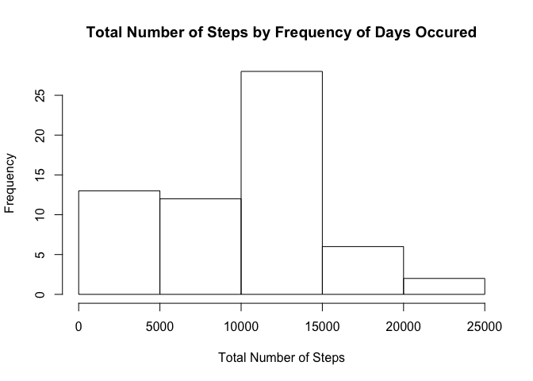

```r
hist(steps_by_date,xlab="Total Number of Steps",
     main="Total Number of Steps by Frequency of Days Occured")
```

### 3. Caluculate Mean and Median Steps Taken Each Day

```r
mean(steps_by_date)
```

```
## [1] 9354.23
```

```r
median(steps_by_date)
```

```
## [1] 10395
```

## Average Daily Activity Pattern

This chunk of code creates a time series plot that compares the average number of steps (y-axis) to the 5-minute time interval. Ultimately this shows when, on average, during the day people in the data set were most or least activity. The final piece of code tells us which interval has the highest average number of steps.

### 1. Time Series Plot of Average Number of Steps Taken

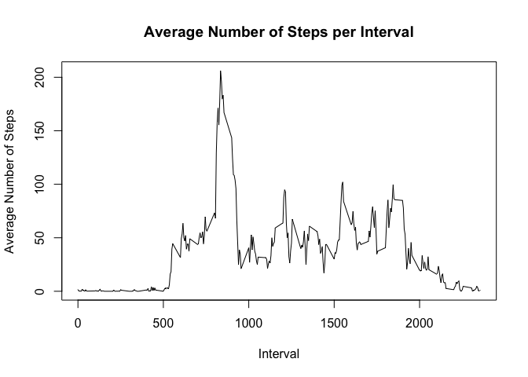

```r
average_daily <- aggregate(activity_date$steps, by=list(activity_date$interval),
       FUN=mean, na.rm=TRUE)
names(average_daily) <- c("interval", "mean")
plot(average_daily$interval, average_daily$mean,
     type = "l", xlab="Interval",
     ylab="Average Number of Steps", main="Average Number of Steps per Interval")
```

### 2. Determine Interval with Maximum Number of Steps (On Average)

```r
average_daily[which.max(average_daily$mean), ]$interval
```

```
## [1] 835
```

## Imputing Missing Values

The presence of missing values, coded as NA, in the data set may introduce bias into some calculations or summaries in the data. For this reason, we will need to impute, or replace, the missing data. The following chunk of code calculates the number of missing values in the data set, devise an imputation strategy, create a new data set that is equal to the original with no missing data, and recreates the histogram, median, and mean steps taken each day.

### 1. Calculate Number of Missing Values in Dataset

```r
sum(is.na(activity_date$steps))
```

```
## [1] 2304
```

### 2. Strategy of Replacing Missing Values

```r
imputed_avgdaily <- average_daily$mean[match(activity_date$interval, average_daily$interval)]
```

### 3. New Data Set with No Missing Values

```r
activity_date_imputed <- transform(activity_date, steps = ifelse(is.na(activity_date$steps),
       yes = imputed_avgdaily, no = activity_date$steps))
total_steps_imputed <- aggregate(steps ~ date, activity_date_imputed, sum)
names(total_steps_imputed) <- c("date", "daily_steps")
sum(is.na(activity_date_imputed))
```

```
## [1] 0
```

### 4. Updated Histogram, Median, and Mean Number of Steps per Day

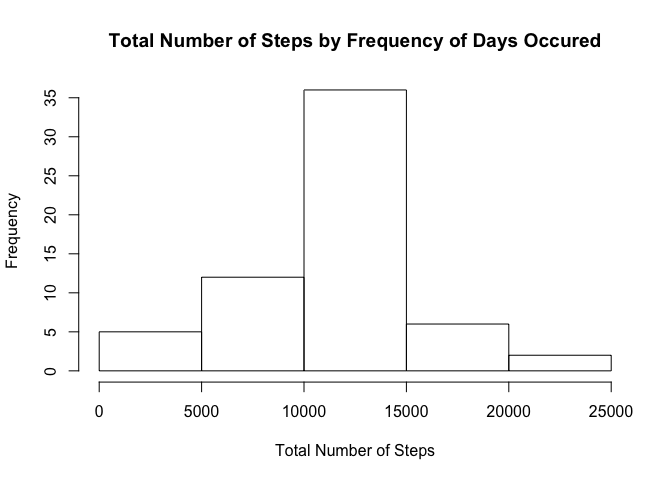

```r
impute_steps_by_date <- tapply(activity_date_imputed$steps,activity_date_imputed$date,
       sum,na.rm=TRUE)
hist(impute_steps_by_date,xlab="Total Number of Steps",
     main="Total Number of Steps by Frequency of Days Occured")
```

```r
mean(impute_steps_by_date)
```

```
## [1] 10766.19
```

```r
median(impute_steps_by_date)
```

```
## [1] 10766.19
```

## Comparing Activity Patterns on Weekdays and Weekends

### 1. Create New Factor Variable with Two Levels - “Weekend” & “Weekday”

```r
activity_weekday <- weekdays(activity_date_imputed$date, abbreviate = FALSE)
activity_datetype <- cbind(activity_date_imputed, activity_weekday)
datetype_level <- list(weekday = c("Monday", "Tuesday","Wednesday", "Thursday",
       "Friday"), weekend = c("Saturday", "Sunday"))
activity_datetype_level <- ifelse(activity_datetype$activity_weekday=="Saturday"
       | activity_datetype$activity_weekday == "Sunday", "Weekend", "Weekday")
activity_datetype_level <- cbind(activity_datetype, activity_datetype_level)
avg_steps_datetype <- aggregate(steps~interval + activity_datetype_level, activity_datetype_level, mean, na.rm = TRUE)
```

### 2. Panel Plot Comparing Activity Levels on Weekends and Weekdays

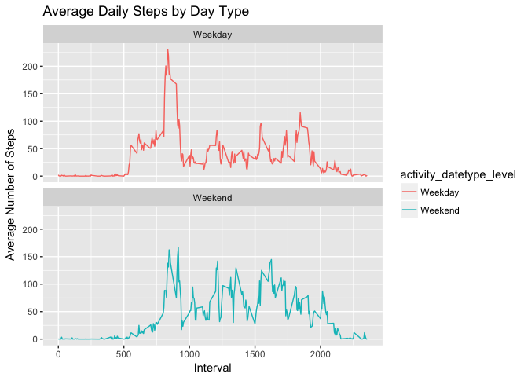

```r
plot<- ggplot(avg_steps_datetype, aes(x = interval , y = steps, color =
       activity_datetype_level)) + geom_line() + labs(title =
       "Average Daily Steps by Day Type", x = "Interval", y = "Average Number of Steps") +
       facet_wrap(~activity_datetype_level, ncol = 1, nrow=2)
print(plot)
```